# *Pf*EIR *vs.* *Pf*PR Sample Noise

House Effects, Trap Method, Age Corrections, …

David Smith

2023-01-12

## Overview

### -

In this paper, we review and re-examine the data describing the *Pf*EIR and the *Pf*PR.

The point of this is to document and quantify several sources of *sampling error,* including potential sources of bias: *house effects;* heterogeneity in the *Pf*PR introduced by the *ages* of the study population; and differences attributed to the methods used to catch/trap mosquitoes. The study is a review of at five studies that have previously examined the relationship or used the data for some other purpose [1–5].

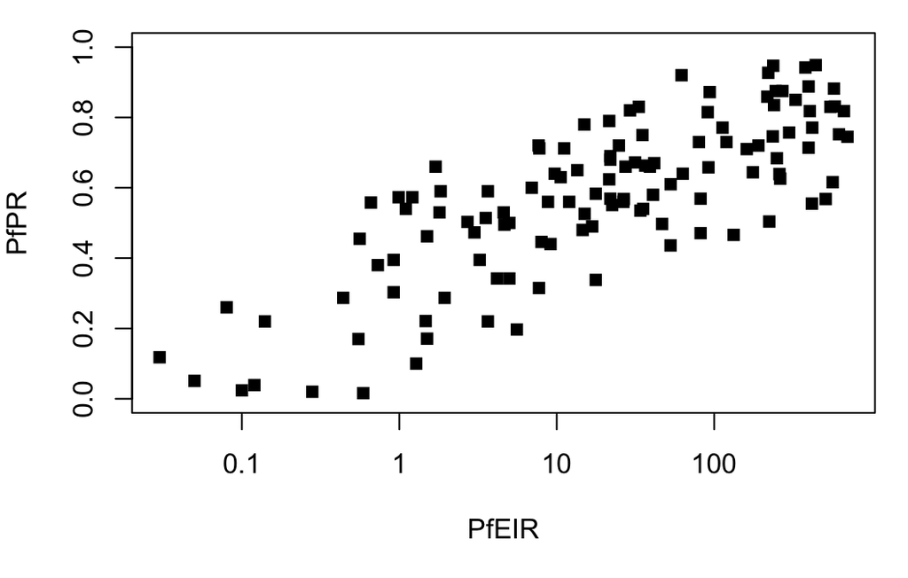

### History

- In 1999, Beier *et al.* published a study that collected data describing estimates of the *Pf*EIR and the *Pf*PR collected at the same time and place [1]. Their analysis showed that the relationship was approximately log-linear.
- In 2005, Hay *et al.* expanded the data, and redid the analysis with a slightly different emphasis [2].
- Later that same year, Smith *et al.* fitted several mechanistic models to the data [3].
- In 2011, Gething *et al.* published global maps of the *Pf*PR, the *Pf*EIR, and the *Pf*$R_C$. The analysis updated the *Pf*EIR - *Pf*PR databases and revisited the relationship [4]
  - The updated data, including new *Pf*PR-*Pf*EIR pairs, was reported in the [$6^{th}$ supplement.](https://static-content.springer.com/esm/art%3A10.1186%2F1475-2875-10-378/MediaObjects/12936_2011_1959_MOESM6_ESM.PDF) The new data set included information about age of the study populations.
  - The *Pf*EIR-*Pf*PR analysis was revisited in the [$7^{th}$ supplement.](https://static-content.springer.com/esm/art%3A10.1186%2F1475-2875-10-378/MediaObjects/12936_2011_1959_MOESM7_ESM.PDF)
- In 2015, Penny *et al.* re-examined the relationship between the *Pf*EIR and the *Pf*PR and identified systematic differences in the relationship based on the method of sampling mosquitoes. The inverted relationship used the *Pf*PR to estimate the distribution of *Pf*EIR at a national level [5]. [Figure 2](https://malariajournal.biomedcentral.com/articles/10.1186/s12936-015-0864-3/figures/2) replots the data.

## House Effects

### -

If the functional form is, indeed, an upper bound then we must be concerned about points that are above the curve. In a previous analysis (see Fig. 2a in Penny, *et al.*, 2015), we identified systematic differences in the relationship based on the method of sampling mosquitoes. Given concerns about sampling bias, we tried to tried to identify which studies they came from. We found the following:

- One set came from Thomson (red points and the red fitted line).
- Two sets of studies came from around Killifi. One is a thesis by Kabiru, and the other a study by Mbogo (orange).
- One set came from Bodker (purple).
- The final set plotted below includes all the other studies not included in one of those sets (black):

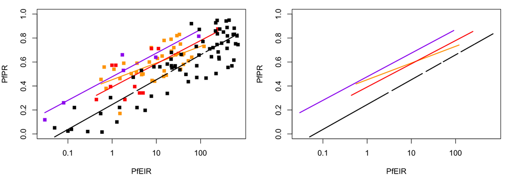

### Kilifi House Effect

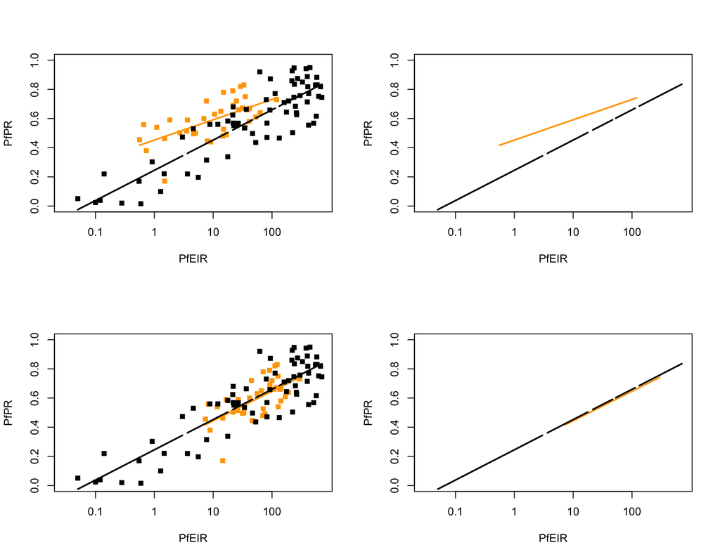

### Thomson House Effect

The study by Thomson reports that they divided their estimates by a factor of 4.4, so we shift it back. Below, we have plotted the EIR estimates that were higher by a factor of 4.4 to reflect what was measured.

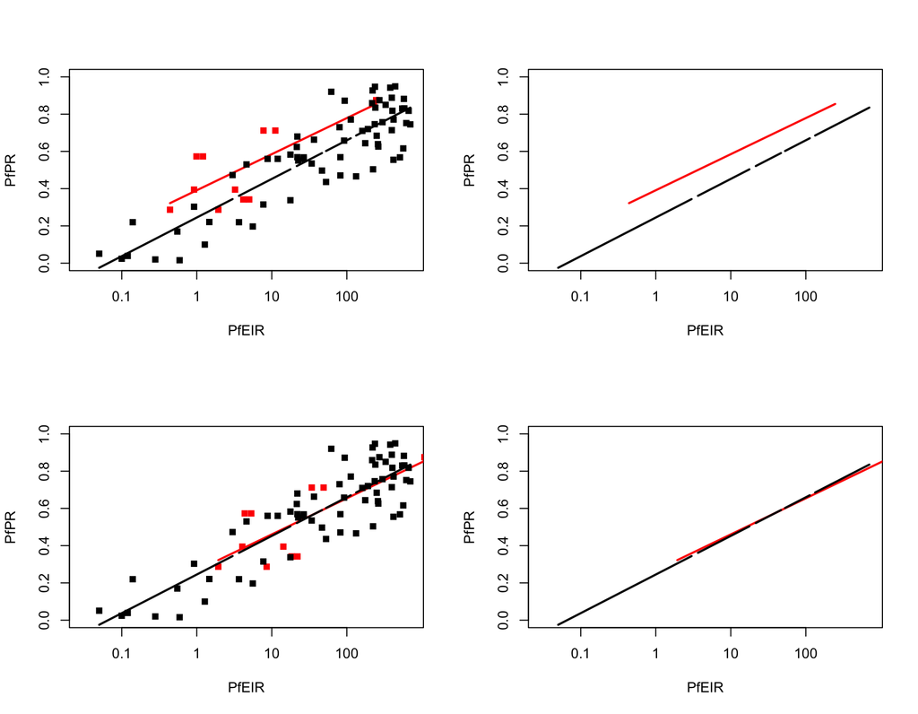

### Bodker House Effect

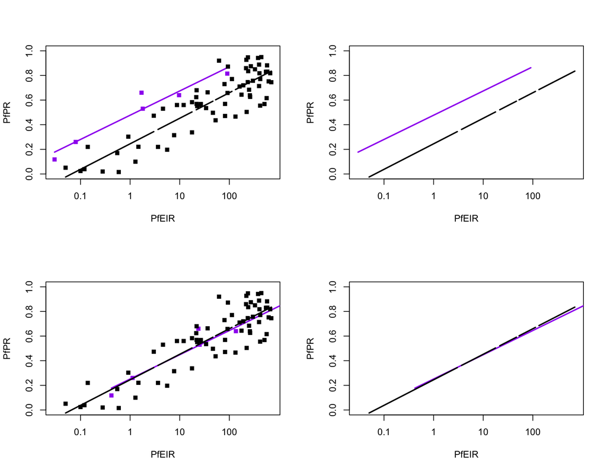

### CDC Light Traps

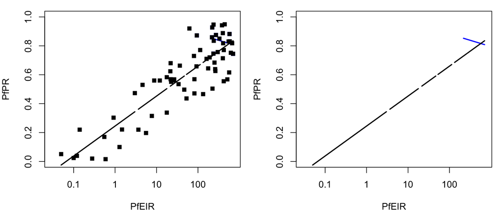

## Revised Data

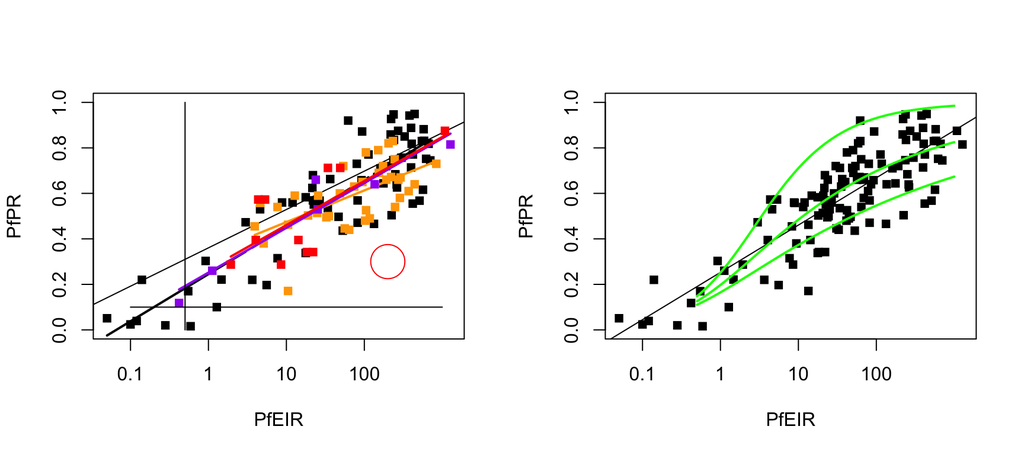

```r
coef(llin2)
```

```
## (Intercept)      NewEIR
##   0.2527677   0.2079209
```

## EIR $\rightarrow$ PR

While the EIR is measured infrequently, the PR is routinely measured in cross-sectional surveys. We can use the PR to estimate the EIR based on an empirical relationship between the EIR and the PR. Here, we start by re-examining an old database describing the EIR and the PR.

As a prelude, we start with a study sought to model the relationship between the EIR and the PR using mechanistic models (Smith, *et al.*, 2005):

$$x = 1 - \left( 1 + \frac{b E
k}{r}\right)^{-1/k}$$

In many ways, we consider this functional form to be a sort of upper bound since it includes super-infection but ignores drug treatment. The parameter $k$ builds in some flexibility. As $k$ becomes very large, heterogeneity plays a larger role. As $k$ becomes very small, the model is equivalent to Ross-Macdonald dynamics. In some sense, we take this as a strong prior on the data. One way it would *not* be an upper bound is if there were a substantial amount of exposure from outside the area, an idea we will explore later.

Here are the data (black points), the log-linear fits, and the function, with different values of $k$. The higher the green curve, the smaller $k$.

We were concerned about bias in the EIR estimates. In particular, we were suspicious of the points around aEIR of 1 that were above our green curves. We noted that these points came from four studies, and we further examined these studies to quantify a house effect. On the bases of those house effects (see below), we made some corrections.

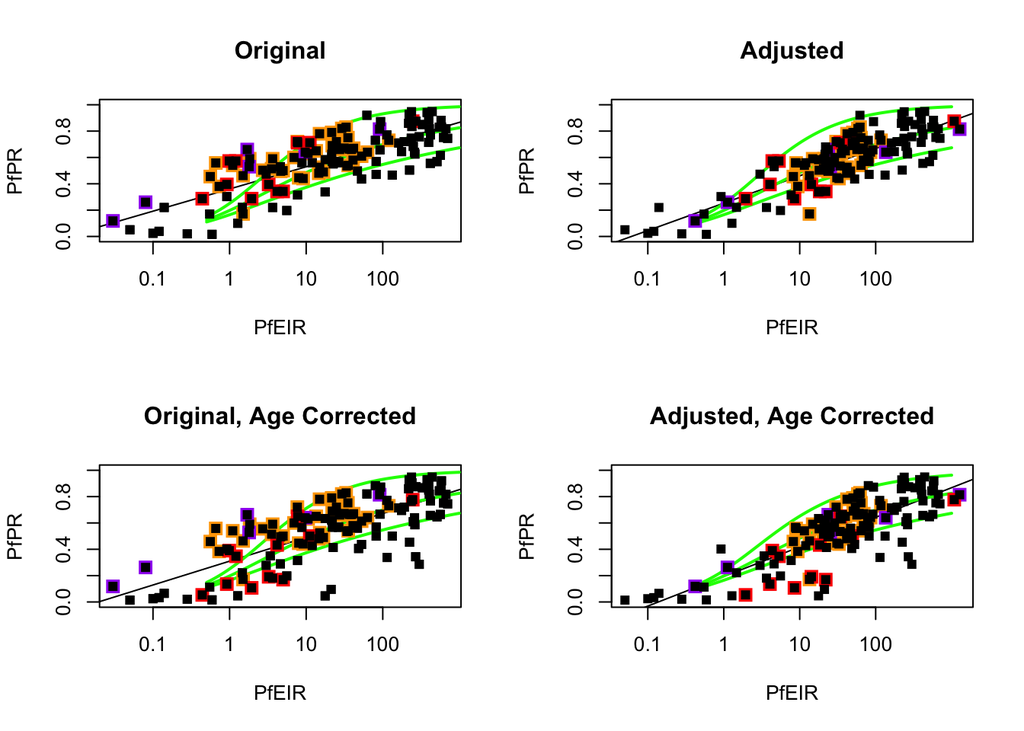

## References

1.

Beier JC, Killeen GF, Githure JI. Short report: Entomologic inoculation rates and Plasmodium falciparum malaria prevalence in Africa. Am J Trop Med Hyg. 1999;61: 109–113. doi:10.4269/ajtmh.1999.61.109

2.

Hay SI, Guerra CA, Tatem AJ, Atkinson PM, Snow RW. Urbanization, malaria transmission and disease burden in Africa. Nat Rev Microbiol. 2005;3: 81–90. doi:10.1038/nrmicro1069

3.

Smith DL, Dushoff J, Snow RW, Hay SI. The entomological inoculation rate and *{}**Plasmodium* *Falciparum{}* infection in African children. Nature. 2005;438: 492–495. doi:10.1038/nature04024

4.

Gething PW, Patil AP, Smith DL, Guerra CA, Elyazar IRF, Johnston GL, et al. A new world malaria map: *Plasmodium* *Falciparum* endemicity in 2010. Malar J. 2011;10: 378. doi:10.1186/1475-2875-10-378

5.

Penny MA, Maire N, Bever CA, Pemberton-Ross P, Briët OJT, Smith DL, et al. Distribution of malaria exposure in endemic countries in Africa considering country levels of effective treatment. Malar J. 2015;14: 384. doi:10.1186/s12936-015-0864-3